# checkin data: Regression analysis

Ming Li

Monday, August 4, 2014

### Target

The goal of this work is to explore the relationships between user’s interest (here represented by “checkin category”) and some contextual factors such as time, weather, sequence, spatial, etc.

First, we load the libraries, functions, and data into the workspace.

Have a look at the data:

```
##       gid             user_id        gender
##  Min.   :   2011   Min.   :884681   male:3580
##  1st Qu.: 412532   1st Qu.:884681
##  Median : 696135   Median :884681
##  Mean   : 653962   Mean   :884681
##  3rd Qu.: 933270   3rd Qu.:884681
##  Max.   :1109291   Max.   :884681
##
##                      venue_id        lat.x          lon.x
##  4f75b8e7e4b0b8451d425348: 154   Min.   :40.5   Min.   :-74.2
##  4cd4dd3e67adf04d8b102a91: 153   1st Qu.:40.7   1st Qu.:-74.0
##  4bd3a9b4462cb713a110df07: 146   Median :40.7   Median :-73.9
##  4c7c2e64aa3ba093dc0daa74: 146   Mean   :40.7   Mean   :-73.9
##  4c81773e74d7b60c6e2577d8: 145   3rd Qu.:40.7   3rd Qu.:-73.9
##  4d74eb5b1a8aa35d8a3e16a7: 145   Max.   :40.9   Max.   :-73.8
##  (Other)                 :2691
##   timestamps.x                             cate_l1
##  Min.   :1.39e+09   Shop & Service             :2053
##  1st Qu.:1.40e+09   Food                       :1249
##  Median :1.40e+09   Arts & Entertainment       : 135
##  Mean   :1.40e+09   Professional & Other Places:  60
##  3rd Qu.:1.40e+09   Nightlife Spot             :  31
##  Max.   :1.40e+09   Outdoors & Recreation      :  24
##                     (Other)                    :  28
##                  cate_l2        datetime
##  Chinese Restaurant  : 446   Min.   :2014-02-01 00:03:40
##  Laundry Service     : 389   1st Qu.:2014-03-27 20:59:10
##  Gym / Fitness Center: 331   Median :2014-05-03 20:37:16
##  Food & Drink Shop   : 327   Mean   :2014-04-28 17:59:25
##  Salon / Barbershop  : 256   3rd Qu.:2014-06-03 15:23:45
##  Gas Station / Garage: 226   Max.   :2014-06-30 23:58:52
##  (Other)             :1605
##               conds         winddird        windspd        temperatur
##  Clear           :1771   Min.   :  0.0   Min.   : 0.00   Min.   :-10.6
##  Overcast        : 815   1st Qu.:  0.0   1st Qu.: 5.60   1st Qu.:  7.2
##  Mostly Cloudy   : 258   Median :  0.0   Median : 9.30   Median : 15.6
##  Partly Cloudy   : 234   Mean   : 80.8   Mean   : 8.91   Mean   : 14.1
##  Scattered Clouds: 197   3rd Qu.:170.0   3rd Qu.:13.00   3rd Qu.: 21.7
##  Light Rain      : 147   Max.   :360.0   Max.   :33.30   Max.   : 30.0
##  (Other)         : 158                   NA's   :241
```

[output cut: 17 more lines]

```
##  Length:3580        Weekend: 946   Shop & Service             :2052
##  Class :character   Workday:2634   Food                       :1251
##  Mode  :character                  Arts & Entertainment       : 135
##                                    Professional & Other Places:  60
##                                    Nightlife Spot             :  31
##                                    Outdoors & Recreation      :  24
##                                    (Other)                    :  27
##    time_diff
##  Min.   :     0
##  1st Qu.:    34
##  Median :    72
##  Mean   :  3605
##  3rd Qu.:   329
##  Max.   :163619
##
```

### Factor selections

#### 1. Chi-square independence test

This is aimed to test whether there are correlations among the factors.

#### 2. Multi-factor analysis of variance (MFA), multi-way ANOVA

ref: http://www.itl.nist.gov/div898/handbook/eda/section3/eda355.htm

Because each factor can take on a certain number of values (i.e. levels of a factor), and the number of levels can vary between factors. For designed experiments, the number of levels for a given factor tends to be small.

#### 3. Multiple correspondence analysis (MCA)

It is used for nominal categorical data, and to detect and represent underlying structures in a dataset. It can be regarded as the counterpart of PCA for categorical data.

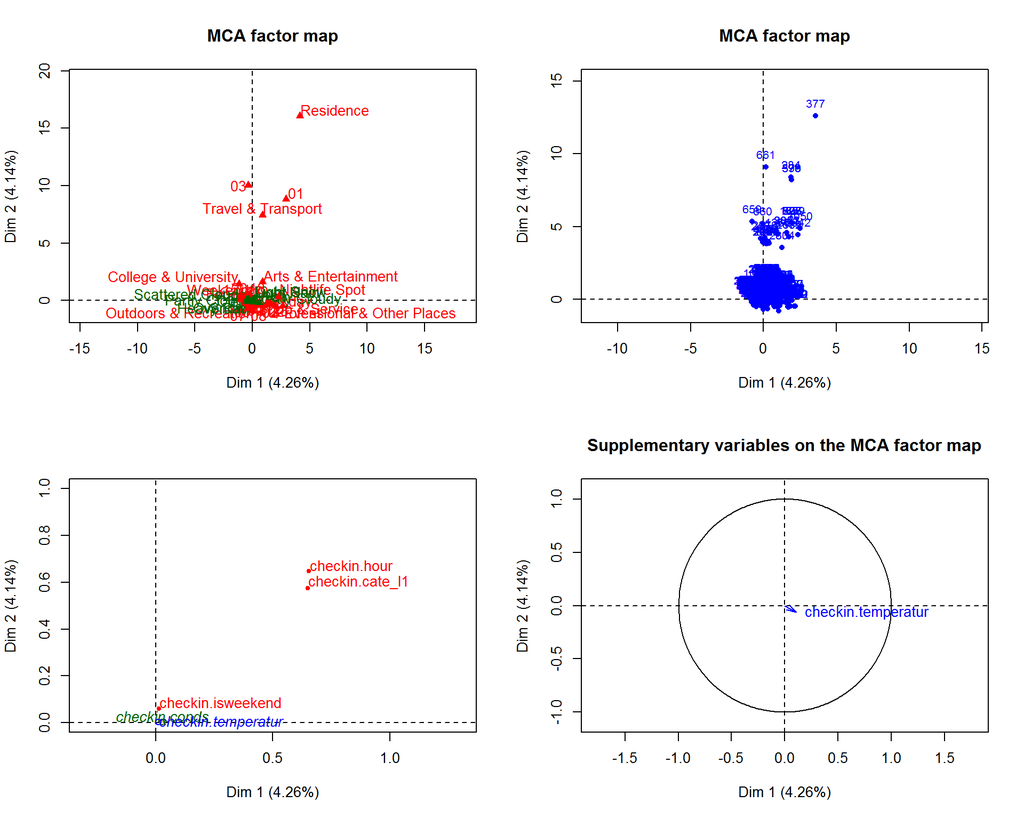

### Regression Model

The data that we are dealing with is categorical. Seveal non-linear regression models are powerful with such kind of data, such as *Multinomial Logistic Regression Model* and *Log Linear Regression model*.

#### 1. Multinomial logistic regression model

This model generalizes logistic regression (binary response) to multiclass problems (more than two possible discrete outomes). It similarly uses a linking function to link the categorical output to a continuous response. $f(x)_{i}=log\frac{P(Y=i)}{P(Y=K)}=\sum \beta_{i,j}\cdot x_{j}$ where $x_{j}$ are the predictors; $K$ is the baseline, and it can be any of the possible output categories; $i$ is any other possible categories except $K$. Therefore, it relies on the assumption of IIA(independence of irrelevant alternatives). Suppose there are $I$ possible categories, then there will be $(I-1)$ equations $f(x)$. $log\frac{P(Y=i)}{P(Y=K)}$ in fact models the log odds of choosing category $i$ against baseline $K$.

Multinomial logistic regression model can deal with both discrete and continuous predictors $x_{i}$. When the predictor is cateogical, it will be treated as dummy variables.

#### 2. Log linear regression model

Log linear analysis allows us to look for relationships among variables in a multiway contingency table. It in fact models the expected frequency of each cell in the contingency table based on all interactions. $F_{ij}=\lambda + \lambda_{i} + \lambda_{j} + \lambda_{ij}$ where $F_{ij}$ is the expected frequency, $\lambda_{i}$ is the influences from varaible $i$, and $\lambda_{j}$ is the influences from varaible $j$. If the interactions between $i$ and $j$ are considered, $\lambda_{ij}$ describes the influences from the interactions.

Since it is based on contingency table, log linear regression model can only deal with categorical data (both predictors and responsed must be categorical). The good side for log linear model is that it is very convienient to perform analysis of variance, and easily specify constrained versions of the saturated model. This is possible with multinomial models using what are called *constrained multinomial models* but it is a bit more tedious.

#### 3. The challenges in using regression

There are several key problems in analyzing the checkin data with regression models.

- determine the variables to be included in tht regression
  - the collinearity should be low; otherwise the model will be unstable;
  - the included variables should contribute to the majority of the total variance in the output response;
- confidence level for the efficients;
- confidence level for the regression model.

Key challenges here includes:

- too many variables:
  - computation;
  - the collinearity diagnostics would be tedious;
  - the interactions between each other would be complicated;
- we have a temporal-spatial problem here:
  - integraing temporal weights for seqential factor;
  - integrating geographical weights for spatial factor;
  - it is not easy to add weights to categorical data;
  - with weights, we will deal with both discrete and continuous variables.

ref: http://www.unistat.com/guide/multinomial-regression/

### Experimental Analysis

#### 1. chi-square tests for independence

We are interested to find whether there’re any relations between them (whether we can reject the null hypothesis $H_{0}$ that these factors are in fact independent from each other). Therefore we begin by taking the several contingency tables from the data.(p.s.: We will leave the spatial factors in the end.)

```r
# venue_cate v.s. hour of day
cate.hour = xtabs(~hour+cate_l1, data=checkin)
cate.hour = as.table(cate.hour[rowSums(cate.hour)>0,colSums(cate.hour)>0])
chisq.test(cate.hour, simulate.p.value = TRUE)
```

```
##
##  Pearson's Chi-squared test with simulated p-value (based on 2000
##  replicates)
##
## data:  cate.hour
## X-squared = 923.6, df = NA, p-value = 0.0004998
```

```r
# venue_cate v.s. categorized hour
cate.hour = xtabs(~hour.i+cate_l1, data=checkin)
cate.hour = as.table(cate.hour[rowSums(cate.hour)>0,colSums(cate.hour)>0])
chisq.test(cate.hour, simulate.p.value = TRUE)
```

```
##
##  Pearson's Chi-squared test with simulated p-value (based on 2000
##  replicates)
##
## data:  cate.hour
## X-squared = 662, df = NA, p-value = 0.0004998
```

```r
# venue_cate v.s. weekend/workday
cate.weekend = xtabs(~isweekend+cate_l1, data=checkin)
cate.weekend = as.table(cate.weekend[rowSums(cate.weekend)>0,colSums(cate.weekend)>0])
chisq.test(cate.weekend, simulate.p.value = TRUE)
```

```
##
##  Pearson's Chi-squared test with simulated p-value (based on 2000
##  replicates)
##
## data:  cate.weekend
## X-squared = 16.94, df = NA, p-value = 0.04848
```

```r
# venue_cate v.s. weather condition
cate.conds = xtabs(~conds+cate_l1, data=checkin)
cate.conds = as.table(cate.conds[rowSums(cate.conds)>0,colSums(cate.conds)>0])
chisq.test(cate.conds, simulate.p.value = TRUE)
```

```
##
##  Pearson's Chi-squared test with simulated p-value (based on 2000
##  replicates)
##
## data:  cate.conds
## X-squared = 108.8, df = NA, p-value = 0.1794
```

```r
# venue_cate v.s. last venue_cate (sequential factor)
cate.cate = xtabs(~last_cate_l1+cate_l1, data=checkin)
cate.cate = as.table(cate.cate[rowSums(cate.cate)>0,colSums(cate.cate)>0])
chisq.test(cate.cate, simulate.p.value = TRUE)
```

```
##
##  Pearson's Chi-squared test with simulated p-value (based on 2000
##  replicates)
##
## data:  cate.cate
## X-squared = 1017, df = NA, p-value = 0.001499
```

At the first glance, the chi-square tests indicate that there should be interactions between category v.s. hour, weekend or not, the last visited cateogry with p-value all below 5%. The p-value for category v.s. weather condition is rather high at 20%. It seems we should accept the null hypothesis that they are not related. However, we should still keep an eye on it because in these chi-square tests, only the single interaction was considered; while these factors might also affet the response in an interacted way.

#### 2. Log-linear analysis

```r
cate.hour = xtabs(~hour.i+cate_l1, data=checkin)
freq.cate.hour = as.data.frame(cate.hour)
loglin.sat.cate.hour = glm(Freq~cate_l1*hour.i,
                           data=freq.cate.hour, family=poisson)
#summary(loglin.sat.cate.hour)
anova(loglin.sat.cate.hour)
```

```
## Analysis of Deviance Table
##
## Model: poisson, link: log
##
## Response: Freq
##
## Terms added sequentially (first to last)
##
##
##                Df Deviance Resid. Df Resid. Dev
## NULL                             119      11309
## cate_l1         9     9340       110       1969
## hour.i         11     1415        99        554
## cate_l1:hour.i 99      554         0          0
```

```r
cate.hour.isweekend = xtabs(~hour.i+cate_l1+isweekend, data=checkin)
freq.cate.hour.isweekend = as.data.frame(cate.hour.isweekend)
loglin.sat.cate.hour.isweekend = glm(Freq~cate_l1*hour.i*isweekend,
                           data=freq.cate.hour.isweekend, family=poisson)
#summary(loglin.sat.cate.hour.isweekend)
anova(loglin.sat.cate.hour.isweekend)
```

```
## Analysis of Deviance Table
##
## Model: poisson, link: log
##
## Response: Freq
##
## Terms added sequentially (first to last)
##
##
##                          Df Deviance Resid. Df Resid. Dev
## NULL                                       239      12385
## cate_l1                   9     9340       230       3045
## hour.i                   11     1415       219       1630
## isweekend                 1      828       218        802
## cate_l1:hour.i           99      554       119        248
## cate_l1:isweekend         9       20       110        228
## hour.i:isweekend         11      142        99         86
## cate_l1:hour.i:isweekend 99       86         0          0
```

#### 3. Multinomial logistic regression

```
library(nnet)
tmodel1<-multinom(cate_l1~ hour.i+isweekend+conds+windspd+temperatur,
                      data=checkin,maxit = 1000)
tsummary1 = summary(tmodel1)
z1 = tsummary1$coefficients/tsummary1$standard.errors
p1 = (1 - pnorm(abs(z1), 0, 1)) * 2
```